# DSCI354-351m-451 Final Exam (CWRU, Pitt, UCF, UTRGV)

## ANSWER 5.b)

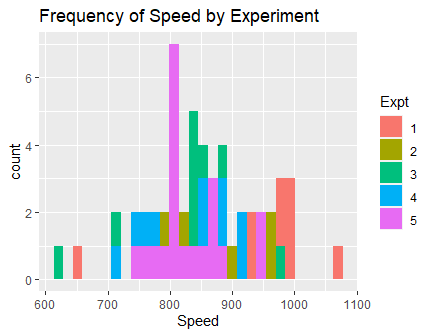

```r
library(ggplot2)

ggplot(data = morley,
       mapping = aes(x = Speed, fill = Expt)
       ) + geom_histogram(position = "identity"
       ) + ggtitle("Frequency of Speed by Experiment")
```

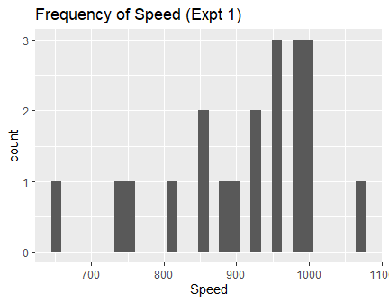

```r
ggplot(data = subset(morley, Expt == 1),
       mapping = aes(x = Speed)
       ) + geom_histogram(position = "identity"
       ) + ggtitle("Frequency of Speed (Expt 1)")
```

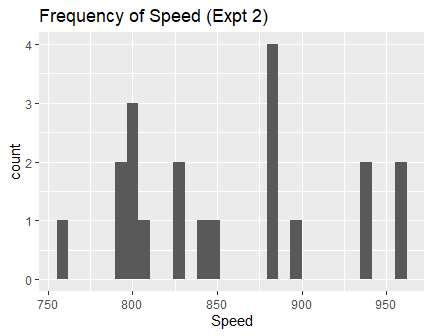

```r
ggplot(data = subset(morley, Expt == 2),
       mapping = aes(x = Speed)
       ) + geom_histogram(position = "identity"
       ) + ggtitle("Frequency of Speed (Expt 2)")
```

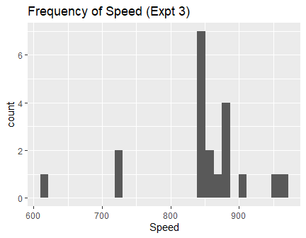

```r
ggplot(data = subset(morley, Expt == 3),
       mapping = aes(x = Speed)
       ) + geom_histogram(position = "identity"
       ) + ggtitle("Frequency of Speed (Expt 3)")
```

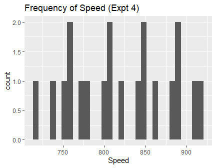

```r
ggplot(data = subset(morley, Expt == 4),
       mapping = aes(x = Speed)
       ) + geom_histogram(position = "identity"
       ) + ggtitle("Frequency of Speed (Expt 4)")
```

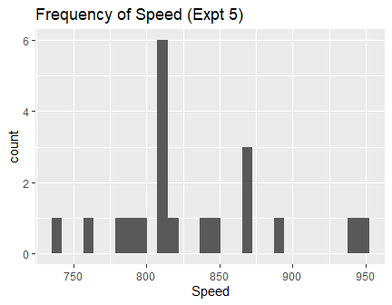

```r
ggplot(data = subset(morley, Expt == 5),
       mapping = aes(x = Speed)
       ) + geom_histogram(position = "identity"
       ) + ggtitle("Frequency of Speed (Expt 5)")
```

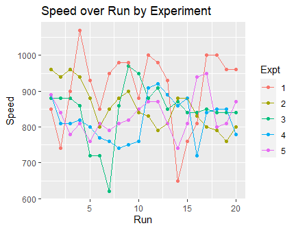

```r
ggplot(data = morley,
       mapping = aes(x = Run,
                     y = Speed,
                     group = Expt,
                     color = Expt,
                     fill = Expt)
       ) + geom_point(
       ) + geom_line(
       ) + ggtitle("Speed over Run by Experiment")
```

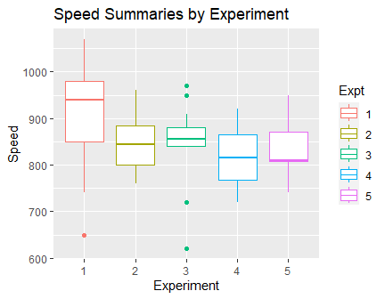

```r
ggplot(data = morley, aes(x = Expt,
                          y = Speed)
       ) + geom_boxplot(aes(color = Expt),
                        show.legend = TRUE
       ) + labs(x = "Experiment",
                y = "Speed",
                color = "Expt"
       ) + ggtitle("Speed Summaries by Experiment")
```

# 6. What is data science? (5 paragraph essay with citations) (4 pts)

What do you find most interesting or exciting

- about data science and EDA?
- What defines data science and how has it come about.
- What are its characteristics, and what are the elements of
  - a data science tool chain,
  - a data science pipeline, and
  - a data analysis.

Use the structure of a 5 paragraph essay

- (Introduction, 3 topic paragraphs, 1 concluding paragraph)
- with citations/references.

### Data Science Experience

Data Science is the science encapsulating the processing of data to generate new information or gain more knowledge about the data in general, to be able to classify it and generalize it as a whole, or infer new things in the future, or whatever else the purpose handling the data is supposed to achieve. Data analysis can be done in 2 ways, one of them being more dominant than the other, and the other to characterize certain models together. Exploratory Data Science is a bit more dominant or powerful to explore new ways to analyze the data, whereas utilizing ML Algorithms and Statistical Models helps to automate the process we have already discovered (in a way, not entirely). I’ve taken two courses alongside this course this semester, where one heavily influences and transform the data analysis process (AI), and one that uses it to protect digital systems (Cybersecurity).

A common concept that went through discussion is, “what do we do with the information we obtain, and how do we interpret it?” The data science process is as follows: 1 - Data Collection Process: get raw data from the real world, reformat and process the data, clean the data; 2 - Data Analysis Process: perform data analysis on it (either EDA or ML Algos/Stat Models). If the data is not sufficient in the Data Analysis Process, go back to the Data Collection Process. Rinse and repeat between these 2 processes until we can clearly and confidently communicate/visualize/report our findings to the world. From these findings, we can build products based on this analysis that can help better the world.

The data scientist must ask, “What data needs to be collected? What do I want it to look like? What question am I supposed to answer with this? Why am I doing this?”, and formulate hypothesis, try again frequently, until there is a new concrete idea has emerged from this analysis that can simplify the data to something more comprehensible, concise, and potentially reusable under similar conditions of data (which then become statistical models) [1]. This idea and the models can then be used to create or automate processes of data handling and processing, quickly determining validity of data, etc.

Something I learned from using this process is to delete faulty records from a database in some database tables. I used the DSCI process to collect, process, interpret, and rinse and repeat for the duration of this semester until I finally was able to create a model, a set of queries, that can fix this faulty data in the database to ensure proper history and record keeping of the data records over the course of their lifetime. I especially used EDA in this context, because some data cannot be fit into certain models, and for this, we have to explore (the understanding of the problem that is trying to be solved changes as time passes) and traverse the data until we can properly understand what it’s trying to say and generalize it under a certain train of thought.

EDA is the willingness to look for things we do and do not believe to be there. There is no hypothesis, no model.So what we do is systematically go through the data, use plots (plot distributions, time series), transform the variables to look into PAIRWISE relationships between the variables, and generate summary statistics (mean, min, max, quartiles, and outliers). Ultimately, the data is NOT the objective, modeling and TIDY data helps, but understanding using the data to represent some aspect of reality is what’s important [1].

1 - [/2-class/2208-351-351m-451-w05b-f2-Inference-DSCIprocess]

# 7. EDA of TCO degradation (4 pts)

This problem will be similar to the LE3 on Degradation of Hard Coat Acrylics.

- But you are given a `.csv` file of a clean and tidy data set.
- You will need to do EDA and make figures and summaries of what you find.
- And list the insights you can develop from your EDA.
- The `.csv` datafile is located in the data subfolder of the `exam-final`

TCO’s are transparent conductive oxides

- Such as ITO, AZO and FTO.
- Heather Lemire Mirletz did her MS thesis on these
- and has a journal paper being published.

Here is the abstract of the paper

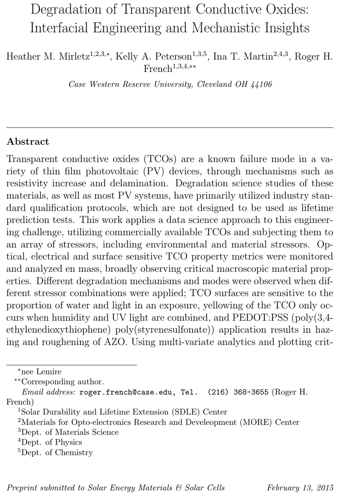

tco-degr abstract

Here is a mindmap of her data science study

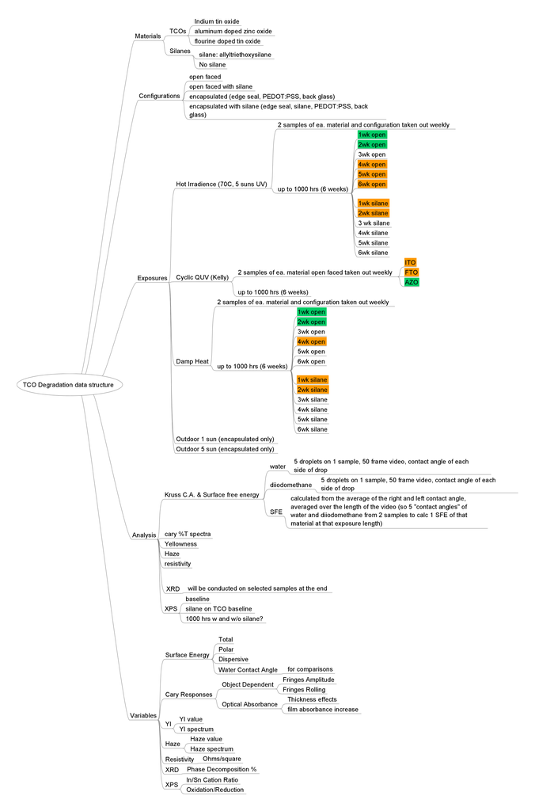

tco-DataStructue

Here is information on the samples studied

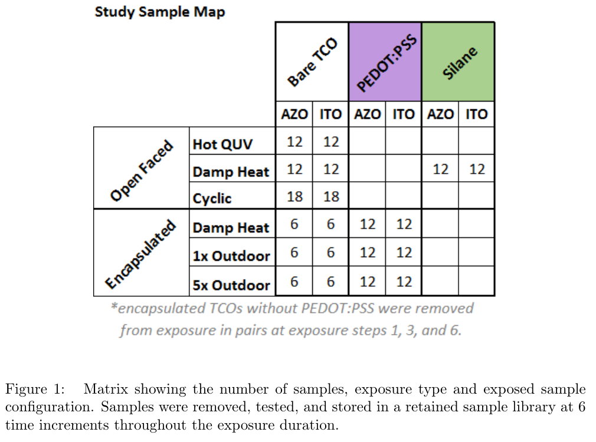

tco-samples

Here is information about the exposures she did

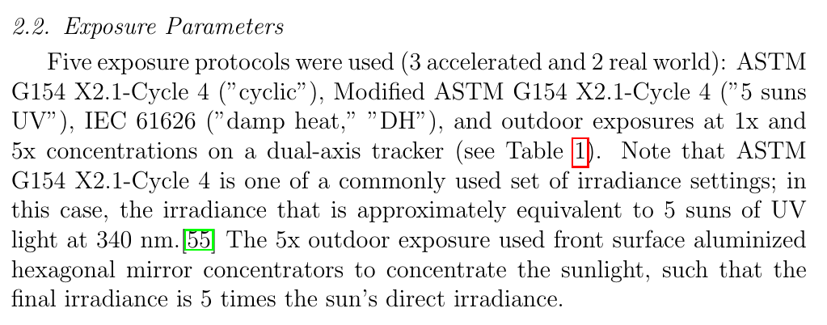

tco-exposures

And a table about the exposures

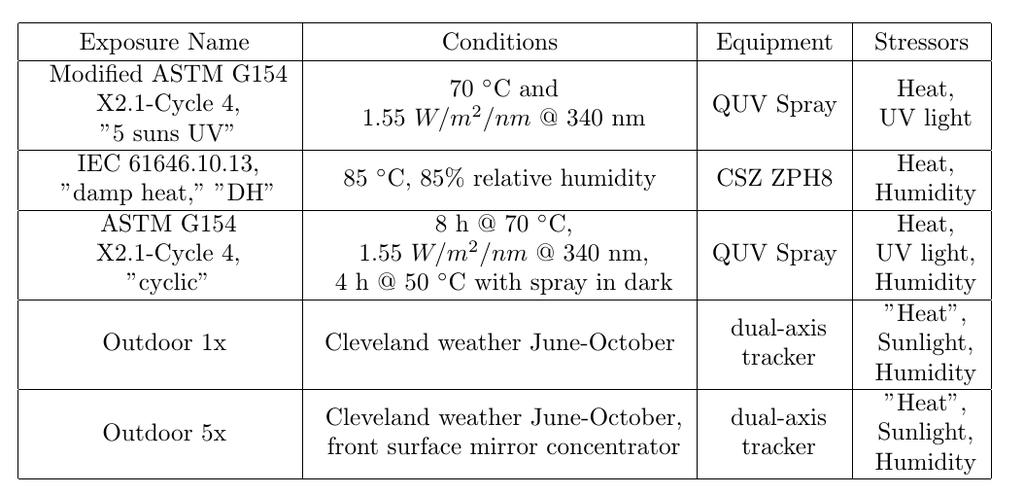

tco-exposures2

Some questions to try to address, showing your results.

- 7.a) Which type of TCO (ITO, AZO, FTO) is most stable?
- 7.b) Which type of Exposure is most aggressive?
- 7.c) How do open vs. encapsulated samples compare.
- 7.d) What other insights can you identify and demonstrate from your EDA?

```r
exposures <- read.csv('data/TCOs.csv')
exposures <- exposures[!(is.na(exposures$SFEtot)), ]
```

ANSWERS:

## ANSWER 7.a)

```r
stats_by_TCO <- exposures %>% group_by(MaterialType
                      ) %>% summarize(mean = mean(SFEtot),
                                      sd = sd(SFEtot))
stats_by_TCO
```

| MaterialType | mean | sd |
| --- | --- | --- |
| AZO | 78.47155 | 10.388323 |
| FTO | 80.35841 | 2.470132 |
| ITO | 72.27171 | 9.556319 |

FTO is most stable

## ANSWER 7.b)

```r
stats_by_exposure <- exposures %>% group_by(ExposureType
                      ) %>% summarize(mean = mean(SFEtot),
                                      sd = sd(SFEtot))
stats_by_exposure
```

| ExposureType | mean | sd |
| --- | --- | --- |
| Cyclic | 82.77318 | 1.653276 |
| DampHeat | 72.70721 | 12.753721 |
| HotQUV | 78.09348 | 3.668049 |

## ANSWER 7.c)

```r
stats_by_silane <- exposures %>% group_by(Silane
                      ) %>% summarize(mean = mean(SFEtot),
                                      sd = sd(SFEtot))
stats_by_silane
```

| Silane | mean | sd |
| --- | --- | --- |
| No | 80.55221 | 2.684032 |
| Yes | 65.42857 | 13.502556 |

## ANSWER 7.d)

couldn’t finish this

# 8. Linear regression on a dataset (4 pts)

Here we’ll use a base R dataset about vapor pressure to discuss the use of linearity in science.

The Dataset contains 19 observations of temperature (Celsius) vs. vapor pressure (mmHg) for mercury

8.a) Start by plotting the data, temperature (x) vs. vapor pressure (y). This relationship is clearly not linear.

However, we may be able to pull a linear relationship from these two metrics. A simplified form of the “Antoine equation” can be used to model the relationship between temperature and vapor pressure:

$$log{P} = A - \frac{B}{T}$$
- $P$ is vapor pressure, $T$ is temperature - $A$ and $B$ are constants representing y intercept and slope

Let’s use this equation to fit our data with a linear model.

8.b) Mutate two new columns from the existing data, for $log{P}$ and for $\frac{1}{T}$

8.c) Create a linear model using lm() using the new columns as your variables

8.d) Plot your linear model with $log{P}$ and $\frac{1}{T}$ axes

8.e) Report the results of your model (model summary) in a table

8.f) What are your approximations for $A$ and $B$ in the simplified Antoine model using this data?

```r
data(pressure)
```

ANSWERS:

[if an answer is in your code block, put `# a)` to show it in your code]

## ANSWER 8.a)

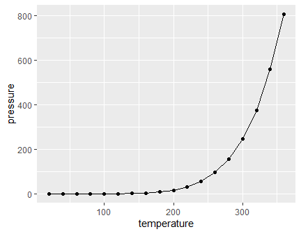

```r
pressure <- pressure[-1, ]
ggplot(pressure,
       aes(x = temperature, y = pressure)
       ) + geom_point(
       ) + geom_line(
       )
```

The plot indicates exponential growth between temperature and pressure

## ANSWER 8.b)

```r
pressure <- pressure %>% mutate(logp = log(pressure), frac = 1 / temperature)
```

## ANSWER 8.c)

```r
regress_pressure <- lm(logp ~ frac, pressure)
regress_pressure
```

```
Call:
lm(formula = logp ~ frac, data = pressure)

Coefficients:
(Intercept)         frac
      4.484     -294.116
```

## ANSWER 8.d)

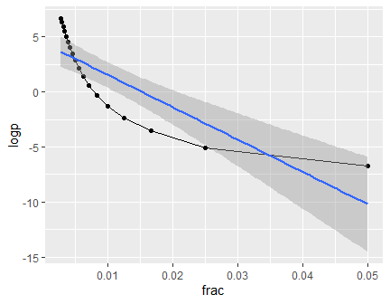

```r
ggplot(pressure,
       aes(x = frac, y = logp)
       ) + geom_point(
       ) + geom_line(
       ) + geom_smooth(method = "lm")
```

## ANSWER 8.e)

```r
summary(regress_pressure)
```

```
Call:
lm(formula = logp ~ frac, data = pressure)

Residuals:
    Min      1Q  Median      3Q     Max
-3.2153 -2.1272  0.0797  1.9102  3.4965

Coefficients:
             Estimate Std. Error t value Pr(>|t|)
(Intercept)    4.4838     0.7244   6.190 1.30e-05 ***
frac        -294.1163    48.7312  -6.035 1.73e-05 ***
---
Signif. codes:  0 ‘***’ 0.001 ‘**’ 0.01 ‘*’ 0.05 ‘.’ 0.1 ‘ ’ 1

Residual standard error: 2.327 on 16 degrees of freedom
Multiple R-squared:  0.6948,    Adjusted R-squared:  0.6757
F-statistic: 36.43 on 1 and 16 DF,  p-value: 1.732e-05
```

## ANSWER 8.f)

y (logP) = b (A) + m (-B) x (1/T)